# Forecasting Stock Price

Maulida Shabrina

For this project, we will use a set of stock data of PT Telekomunikasi Indonesia Tbk (TLKM.JK) for the last three years (May 22, 2019, to May 20, 2022). This project aims to understand and model the volatility patterns of the stock prices using time series analysis techniques. We will explore the applicability of ARIMA and ARCH-GARCH models to predict the future behavior of the stock returns.

```r
library(TSA)
library(aTSA)
library(forecast)
library(tseries)
library(moments)
library(lmtest)
library(FinTS)
library(fGarch)
# import data
data1 = read.delim("clipboard", header = FALSE)
data1
```

```
##               V1
## 1    0.033336364
## 2    0.024292763
## 3    0.018494587
## 4   -0.034623941
## 5    0.024097546
## 6    0.000000000
## 7    0.031252420
## 8    0.000000000
## 9    0.000000000
## 10   0.000000000
## 11   0.000000000
## 12   0.000000000
## 13   0.035268218
## 14  -0.004962781
```

[output cut: 719 more lines]

```r
# check if the object is a time series
is.ts(data1)
```

```
## [1] FALSE
```

```r
data2 = ts(data1)
```

```r
# check if data2 is a time series data
is.ts(data2)
```

```
## [1] TRUE
```

It is evident that the data is already in the form of time series data.

```r
# Stationary test
adf.test(data2)
```

```
##
##  Augmented Dickey-Fuller Test
##
## data:  data2
## Dickey-Fuller = -9.6104, Lag order = 9, p-value = 0.01
## alternative hypothesis: stationary
```

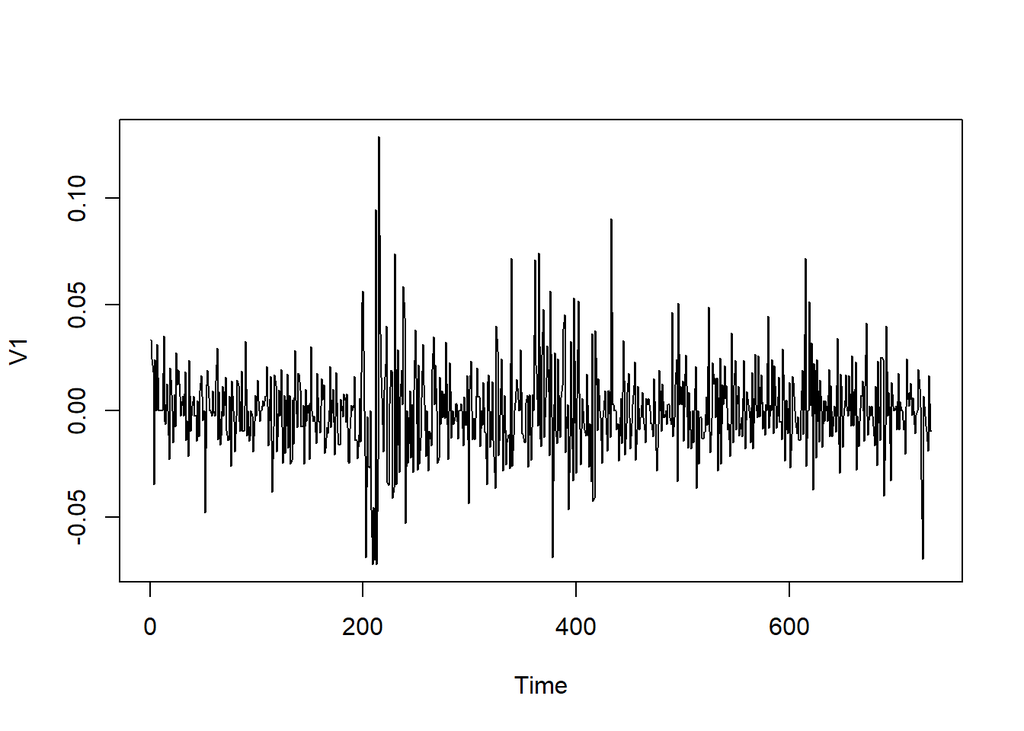

```r
plot(data2)
```

Since the p-value = 0.01 < ⍺ = 0.05, H₀ is rejected. Therefore, it can be concluded that the time series data is stationary with respect to the mean.

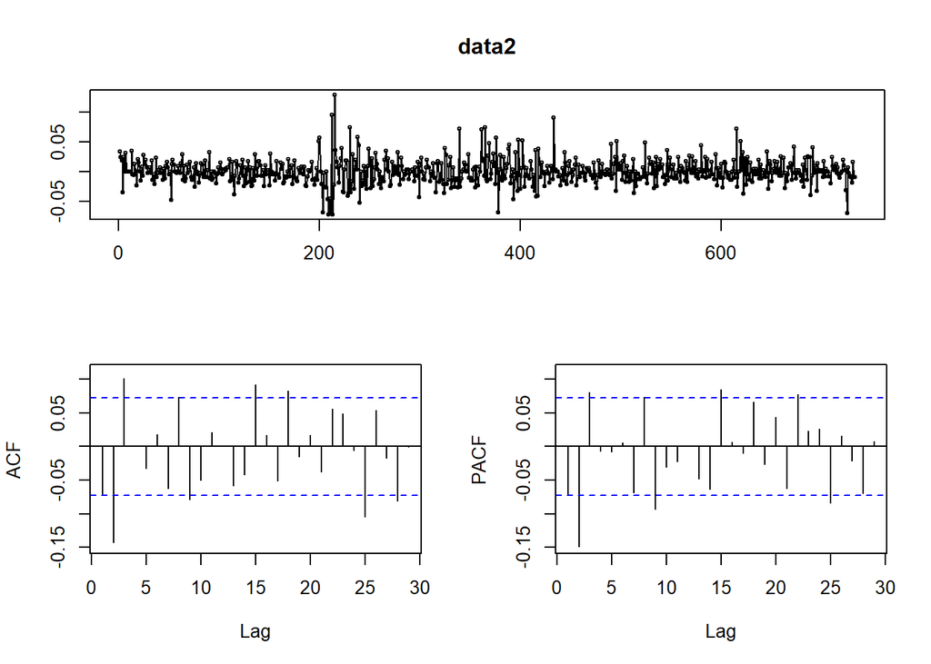

```r
tsdisplay(data2)
```

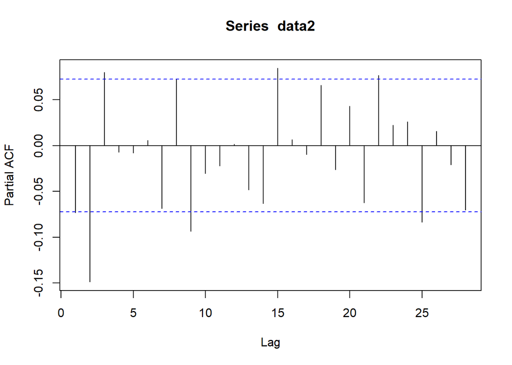

```r
# PACF plot
pacf(data2)
```

In the PACF plot, we can determine the order $p$. From the first 4 lags, the last significant lag is lag 3, hence $p = 3$.

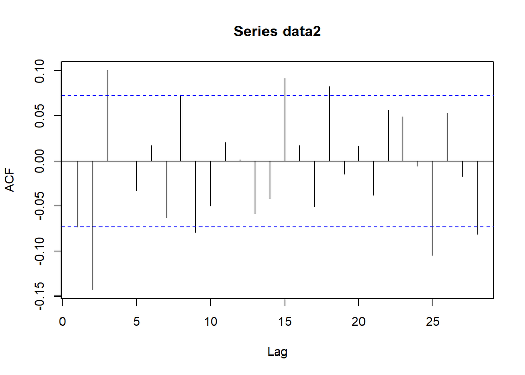

```r
# ACF plot
acf(data2)
```

```r
# Overfitting
arima1 <- Arima(data2, order=c(3,0,3), include.constant = T)
arima2 <- Arima(data2, order=c(3,0,2), include.constant = T)
arima3 <- Arima(data2, order=c(3,0,1), include.constant = T)
arima4 <- Arima(data2, order=c(3,0,0), include.constant = T)
arima5 <- Arima(data2, order=c(2,0,3), include.constant = T)
arima6 <- Arima(data2, order=c(2,0,2), include.constant = T)
arima7 <- Arima(data2, order=c(2,0,1), include.constant = T)
arima8 <- Arima(data2, order=c(2,0,0), include.constant = T)
arima9 <- Arima(data2, order=c(1,0,3), include.constant = T)
arima10 <- Arima(data2, order=c(1,0,2), include.constant = T)
arima11 <- Arima(data2, order=c(1,0,1), include.constant = T)
arima12 <- Arima(data2, order=c(1,0,0), include.constant = T)
arima13 <- Arima(data2, order=c(0,0,3), include.constant = T)
arima14 <- Arima(data2, order=c(0,0,2), include.constant = T)
arima15 <- Arima(data2, order=c(0,0,1), include.constant = T)
arima16 <- Arima(data2, order=c(3,0,3), include.constant = F)
arima17 <- Arima(data2, order=c(3,0,2), include.constant = F)
arima18 <- Arima(data2, order=c(3,0,1), include.constant = F)
arima19 <- Arima(data2, order=c(3,0,0), include.constant = F)
arima20 <- Arima(data2, order=c(2,0,3), include.constant = F)
arima21 <- Arima(data2, order=c(2,0,2), include.constant = F)
arima22 <- Arima(data2, order=c(2,0,1), include.constant = F)
arima23 <- Arima(data2, order=c(2,0,0), include.constant = F)
arima24 <- Arima(data2, order=c(1,0,3), include.constant = F)
arima25 <- Arima(data2, order=c(1,0,2), include.constant = F)
arima26 <- Arima(data2, order=c(1,0,1), include.constant = F)
arima27 <- Arima(data2, order=c(1,0,0), include.constant = F)
arima28 <- Arima(data2, order=c(0,0,3), include.constant = F)
arima29 <- Arima(data2, order=c(0,0,2), include.constant = F)
arima30 <- Arima(data2, order=c(0,0,1), include.constant = F)
```

```r
# Test each possible model
coeftest(arima1)
```

```
##
## z test of coefficients:
##
##              Estimate  Std. Error z value  Pr(>|z|)
## ar1       -1.50788393  0.19933394 -7.5646 3.890e-14 ***
## ar2       -0.78369251  0.30908394 -2.5355   0.01123 *
## ar3       -0.02743264  0.17592698 -0.1559   0.87609
## ma1        1.45523677  0.19624257  7.4155 1.212e-13 ***
## ma2        0.55240875  0.31585435  1.7489   0.08030 .
## ma3       -0.15733759  0.17513750 -0.8984   0.36899
## intercept  0.00037203  0.00063497  0.5859   0.55794
## ---
## Signif. codes:  0 '***' 0.001 '**' 0.01 '*' 0.05 '.' 0.1 ' ' 1
```

```r
coeftest(arima2)
```

```
##
## z test of coefficients:
##
##              Estimate  Std. Error  z value  Pr(>|z|)
## ar1       -1.67295503  0.06317856 -26.4798 < 2.2e-16 ***
## ar2       -1.04893979  0.07069794 -14.8369 < 2.2e-16 ***
## ar3       -0.17400370  0.03964948  -4.3885 1.141e-05 ***
## ma1        1.62494214  0.05447377  29.8298 < 2.2e-16 ***
## ma2        0.83699088  0.05259188  15.9148 < 2.2e-16 ***
## intercept  0.00036951  0.00065718   0.5623    0.5739
## ---
## Signif. codes:  0 '***' 0.001 '**' 0.01 '*' 0.05 '.' 0.1 ' ' 1
```

```r
coeftest(arima3)
```

```
##
## z test of coefficients:
##
##              Estimate  Std. Error z value Pr(>|z|)
## ar1       -0.15023323  0.40379793 -0.3721 0.709855
## ar2       -0.14905425  0.05033784 -2.9611 0.003066 **
## ar3        0.06791937  0.07288583  0.9319 0.351409
## ma1        0.07771232  0.40434705  0.1922 0.847592
## intercept  0.00036701  0.00065375  0.5614 0.574528
## ---
## Signif. codes:  0 '***' 0.001 '**' 0.01 '*' 0.05 '.' 0.1 ' ' 1
```

```r
coeftest(arima4)
```

```
##
## z test of coefficients:
##
##              Estimate  Std. Error z value  Pr(>|z|)
## ar1       -0.07263749  0.03689507 -1.9688   0.04898 *
## ar2       -0.14253538  0.03662357 -3.8919 9.946e-05 ***
## ar3        0.07950149  0.03691033  2.1539   0.03125 *
## intercept  0.00037551  0.00065771  0.5709   0.56805
## ---
## Signif. codes:  0 '***' 0.001 '**' 0.01 '*' 0.05 '.' 0.1 ' ' 1
```

```r
coeftest(arima4)
```

```
##
## z test of coefficients:
##
##              Estimate  Std. Error z value  Pr(>|z|)
## ar1       -0.07263749  0.03689507 -1.9688   0.04898 *
## ar2       -0.14253538  0.03662357 -3.8919 9.946e-05 ***
## ar3        0.07950149  0.03691033  2.1539   0.03125 *
## intercept  0.00037551  0.00065771  0.5709   0.56805
## ---
## Signif. codes:  0 '***' 0.001 '**' 0.01 '*' 0.05 '.' 0.1 ' ' 1
```

```r
coeftest(arima5)
```

```
##
## z test of coefficients:
##
##              Estimate  Std. Error  z value  Pr(>|z|)
## ar1       -1.47945184  0.06455671 -22.9171 < 2.2e-16 ***
## ar2       -0.73881275  0.06999945 -10.5546 < 2.2e-16 ***
## ma1        1.42789302  0.07005672  20.3820 < 2.2e-16 ***
## ma2        0.50860868  0.10008922   5.0816 3.744e-07 ***
## ma3       -0.18297442  0.04083846  -4.4804 7.449e-06 ***
## intercept  0.00037445  0.00063265   0.5919    0.5539
## ---
## Signif. codes:  0 '***' 0.001 '**' 0.01 '*' 0.05 '.' 0.1 ' ' 1
```

```r
coeftest(arima6)
```

```
##
## z test of coefficients:
##
##              Estimate  Std. Error z value Pr(>|z|)
## ar1       -0.53636028  0.20969462 -2.5578  0.01053 *
## ar2       -0.32723560  0.14581238 -2.2442  0.02482 *
## ma1        0.46536551  0.22015248  2.1138  0.03453 *
## ma2        0.15026887  0.15074541  0.9968  0.31884
## intercept  0.00037314  0.00064757  0.5762  0.56447
## ---
## Signif. codes:  0 '***' 0.001 '**' 0.01 '*' 0.05 '.' 0.1 ' ' 1
```

```r
coeftest(arima7)
```

```
##
## z test of coefficients:
##
##              Estimate  Std. Error z value  Pr(>|z|)
## ar1       -0.42882650  0.14628673 -2.9314  0.003374 **
## ar2       -0.18034201  0.03640824 -4.9533 7.295e-07 ***
## ma1        0.35380435  0.14646093  2.4157  0.015705 *
## intercept  0.00037166  0.00062896  0.5909  0.554572
## ---
## Signif. codes:  0 '***' 0.001 '**' 0.01 '*' 0.05 '.' 0.1 ' ' 1
```

```r
coeftest(arima8)
```

```
##
## z test of coefficients:
##
##              Estimate  Std. Error z value  Pr(>|z|)
## ar1       -0.08471093  0.03658339 -2.3156   0.02058 *
## ar2       -0.14961219  0.03659225 -4.0886 4.339e-05 ***
## intercept  0.00036866  0.00060739  0.6070   0.54388
## ---
## Signif. codes:  0 '***' 0.001 '**' 0.01 '*' 0.05 '.' 0.1 ' ' 1
```

```r
coeftest(arima9)
```

```
##
## z test of coefficients:
##
##              Estimate  Std. Error z value Pr(>|z|)
## ar1        0.06595299  0.28691730  0.2299 0.818195
## ma1       -0.13949636  0.28436887 -0.4905 0.623747
## ma2       -0.12565265  0.03975345 -3.1608 0.001573 **
## ma3        0.09545583  0.05111198  1.8676 0.061820 .
## intercept  0.00037512  0.00066453  0.5645 0.572418
## ---
## Signif. codes:  0 '***' 0.001 '**' 0.01 '*' 0.05 '.' 0.1 ' ' 1
```

```r
coeftest(arima10)
```

```
##
## z test of coefficients:
##
##              Estimate  Std. Error z value Pr(>|z|)
## ar1       -0.32014759  0.14710259 -2.1764  0.02953 *
## ma1        0.25117842  0.14418475  1.7421  0.08150 .
## ma2       -0.15858206  0.03372281 -4.7025 2.57e-06 ***
## intercept  0.00037184  0.00062004  0.5997  0.54870
## ---
## Signif. codes:  0 '***' 0.001 '**' 0.01 '*' 0.05 '.' 0.1 ' ' 1
```

```r
coeftest(arima11)
```

```
##
## z test of coefficients:
##
##              Estimate  Std. Error z value Pr(>|z|)
## ar1        0.41843605  0.22778874  1.8369  0.06622 .
## ma1       -0.52142308  0.21333533 -2.4441  0.01452 *
## intercept  0.00036141  0.00062165  0.5814  0.56099
## ---
## Signif. codes:  0 '***' 0.001 '**' 0.01 '*' 0.05 '.' 0.1 ' ' 1
```

```r
coeftest(arima12)
```

```
##
## z test of coefficients:
##
##              Estimate  Std. Error z value Pr(>|z|)
## ar1       -0.07328098  0.03688471 -1.9868  0.04695 *
## intercept  0.00037483  0.00070590  0.5310  0.59542
## ---
## Signif. codes:  0 '***' 0.001 '**' 0.01 '*' 0.05 '.' 0.1 ' ' 1
```

```r
coeftest(arima13)
```

```
##
## z test of coefficients:
##
##              Estimate  Std. Error z value  Pr(>|z|)
## ma1       -0.07457619  0.03678766 -2.0272 0.0426413 *
## ma2       -0.12941443  0.03593683 -3.6012 0.0003168 ***
## ma3        0.08646875  0.03568695  2.4230 0.0153938 *
## intercept  0.00037612  0.00065977  0.5701 0.5686185
## ---
## Signif. codes:  0 '***' 0.001 '**' 0.01 '*' 0.05 '.' 0.1 ' ' 1
```

```r
coeftest(arima14)
```

```
##
## z test of coefficients:
##
##              Estimate  Std. Error z value  Pr(>|z|)
## ma1       -0.06022097  0.03737051 -1.6115 0.1070802
## ma2       -0.13540215  0.03736452 -3.6238 0.0002903 ***
## intercept  0.00037108  0.00060419  0.6142 0.5390958
## ---
## Signif. codes:  0 '***' 0.001 '**' 0.01 '*' 0.05 '.' 0.1 ' ' 1
```

```r
coeftest(arima15)
```

```
##
## z test of coefficients:
##
##              Estimate  Std. Error z value Pr(>|z|)
## ma1       -0.09954190  0.04193892 -2.3735  0.01762 *
## intercept  0.00037511  0.00068162  0.5503  0.58210
## ---
## Signif. codes:  0 '***' 0.001 '**' 0.01 '*' 0.05 '.' 0.1 ' ' 1
```

```r
coeftest(arima16)
```

```
##
## z test of coefficients:
##
##      Estimate Std. Error z value  Pr(>|z|)
## ar1 -1.509534   0.200128 -7.5429 4.598e-14 ***
## ar2 -0.788430   0.309575 -2.5468   0.01087 *
## ar3 -0.030501   0.176350 -0.1730   0.86269
## ma1  1.457107   0.197069  7.3939 1.426e-13 ***
## ma2  0.557439   0.316441  1.7616   0.07814 .
## ma3 -0.154084   0.175478 -0.8781   0.37990
## ---
## Signif. codes:  0 '***' 0.001 '**' 0.01 '*' 0.05 '.' 0.1 ' ' 1
```

```r
coeftest(arima17)
```

```
##
## z test of coefficients:
##
##      Estimate Std. Error  z value  Pr(>|z|)
## ar1 -1.672849   0.063224 -26.4590 < 2.2e-16 ***
## ar2 -1.048663   0.070692 -14.8342 < 2.2e-16 ***
## ar3 -0.173437   0.039702  -4.3684 1.251e-05 ***
## ma1  1.625050   0.054516  29.8089 < 2.2e-16 ***
## ma2  0.837350   0.052625  15.9117 < 2.2e-16 ***
## ---
## Signif. codes:  0 '***' 0.001 '**' 0.01 '*' 0.05 '.' 0.1 ' ' 1
```

```r
coeftest(arima18)
```

```
##
## z test of coefficients:
##
##      Estimate Std. Error z value Pr(>|z|)
## ar1 -0.137934   0.407473 -0.3385 0.734978
## ar2 -0.147671   0.050367 -2.9319 0.003369 **
## ar3  0.070122   0.072659  0.9651 0.334503
## ma1  0.066189   0.408161  0.1622 0.871177
## ---
## Signif. codes:  0 '***' 0.001 '**' 0.01 '*' 0.05 '.' 0.1 ' ' 1
```

```r
coeftest(arima19)
```

```
##
## z test of coefficients:
##
##      Estimate Std. Error z value Pr(>|z|)
## ar1 -0.072207   0.036895 -1.9571 0.050340 .
## ar2 -0.142144   0.036625 -3.8810 0.000104 ***
## ar3  0.079876   0.036913  2.1639 0.030471 *
## ---
## Signif. codes:  0 '***' 0.001 '**' 0.01 '*' 0.05 '.' 0.1 ' ' 1
```

```r
coeftest(arima20)
```

```
##
## z test of coefficients:
##
##      Estimate Std. Error  z value  Pr(>|z|)
## ar1 -1.479491   0.064553 -22.9189 < 2.2e-16 ***
## ar2 -0.738671   0.069932 -10.5627 < 2.2e-16 ***
## ma1  1.428546   0.070070  20.3874 < 2.2e-16 ***
## ma2  0.509587   0.100016   5.0951 3.486e-07 ***
## ma3 -0.182415   0.040820  -4.4687 7.869e-06 ***
## ---
## Signif. codes:  0 '***' 0.001 '**' 0.01 '*' 0.05 '.' 0.1 ' ' 1
```

```r
coeftest(arima21)
```

```
##
## z test of coefficients:
##
##     Estimate Std. Error z value Pr(>|z|)
## ar1 -0.54147    0.20960 -2.5833 0.009786 **
## ar2 -0.32731    0.14656 -2.2333 0.025532 *
## ma1  0.47114    0.22013  2.1403 0.032334 *
## ma2  0.15071    0.15163  0.9940 0.320240
## ---
## Signif. codes:  0 '***' 0.001 '**' 0.01 '*' 0.05 '.' 0.1 ' ' 1
```

```r
coeftest(arima22)
```

```
##
## z test of coefficients:
##
##      Estimate Std. Error z value  Pr(>|z|)
## ar1 -0.429873   0.146144 -2.9414  0.003267 **
## ar2 -0.180036   0.036408 -4.9450 7.614e-07 ***
## ma1  0.355119   0.146288  2.4275  0.015202 *
## ---
## Signif. codes:  0 '***' 0.001 '**' 0.01 '*' 0.05 '.' 0.1 ' ' 1
```

```r
coeftest(arima23)
```

```
##
## z test of coefficients:
##
##      Estimate Std. Error z value  Pr(>|z|)
## ar1 -0.084307   0.036587 -2.3043    0.0212 *
## ar2 -0.149228   0.036596 -4.0777 4.548e-05 ***
## ---
## Signif. codes:  0 '***' 0.001 '**' 0.01 '*' 0.05 '.' 0.1 ' ' 1
```

```r
coeftest(arima24)
```

```
##
## z test of coefficients:
##
##      Estimate Std. Error z value Pr(>|z|)
## ar1  0.068381   0.286913  0.2383 0.811623
## ma1 -0.141586   0.284354 -0.4979 0.618541
## ma2 -0.125142   0.039705 -3.1518 0.001623 **
## ma3  0.096076   0.050970  1.8849 0.059437 .
## ---
## Signif. codes:  0 '***' 0.001 '**' 0.01 '*' 0.05 '.' 0.1 ' ' 1
```

```r
coeftest(arima25)
```

```
##
## z test of coefficients:
##
##      Estimate Std. Error z value  Pr(>|z|)
## ar1 -0.317007   0.147735 -2.1458   0.03189 *
## ma1  0.248500   0.144846  1.7156   0.08623 .
## ma2 -0.158107   0.033727 -4.6878 2.762e-06 ***
## ---
## Signif. codes:  0 '***' 0.001 '**' 0.01 '*' 0.05 '.' 0.1 ' ' 1
```

```r
coeftest(arima26)
```

```
##
## z test of coefficients:
##
##     Estimate Std. Error z value Pr(>|z|)
## ar1  0.41335    0.22296  1.8539  0.06375 .
## ma1 -0.51637    0.20899 -2.4708  0.01348 *
## ---
## Signif. codes:  0 '***' 0.001 '**' 0.01 '*' 0.05 '.' 0.1 ' ' 1
```

```r
coeftest(arima27)
```

```
##
## z test of coefficients:
##
##      Estimate Std. Error z value Pr(>|z|)
## ar1 -0.072954   0.036887 -1.9778  0.04795 *
## ---
## Signif. codes:  0 '***' 0.001 '**' 0.01 '*' 0.05 '.' 0.1 ' ' 1
```

```r
coeftest(arima28)
```

```
##
## z test of coefficients:
##
##      Estimate Std. Error z value  Pr(>|z|)
## ma1 -0.074230   0.036792 -2.0176 0.0436360 *
## ma2 -0.129005   0.035920 -3.5915 0.0003288 ***
## ma3  0.086788   0.035672  2.4329 0.0149777 *
## ---
## Signif. codes:  0 '***' 0.001 '**' 0.01 '*' 0.05 '.' 0.1 ' ' 1
```

```r
coeftest(arima29)
```

```
##
## z test of coefficients:
##
##      Estimate Std. Error z value  Pr(>|z|)
## ma1 -0.059800   0.037375 -1.6000 0.1095984
## ma2 -0.134992   0.037349 -3.6143 0.0003011 ***
## ---
## Signif. codes:  0 '***' 0.001 '**' 0.01 '*' 0.05 '.' 0.1 ' ' 1
```

```r
coeftest(arima30)
```

```
##
## z test of coefficients:
##
##      Estimate Std. Error z value Pr(>|z|)
## ma1 -0.099092   0.041926 -2.3635   0.0181 *
## ---
## Signif. codes:  0 '***' 0.001 '**' 0.01 '*' 0.05 '.' 0.1 ' ' 1
```

Based on the testing of each possible model, the suitable models are ARIMA (3, 0, 2), ARIMA (2, 0, 3), ARIMA (2, 0, 1), ARIMA (2, 0, 0), ARIMA (1, 0, 0), ARIMA (0, 0, 3), and ARIMA (0, 0, 1) because all variables are significant to the model.

```
##
##  Ljung-Box test
##
## data:  Residuals from ARIMA(3,0,2) with zero mean
## Q* = 7.0501, df = 5, p-value = 0.2169
##
## Model df: 5.   Total lags used: 10
```

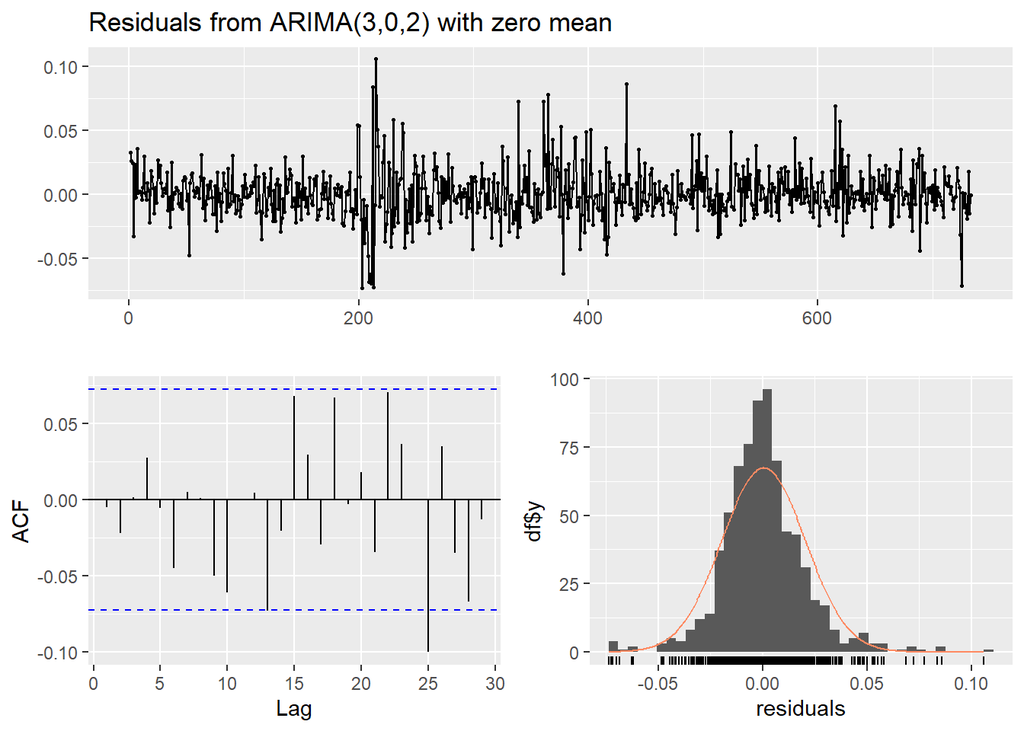

```r
# Diagnostic, stationary, and normality test

check_arima <- function(arima_model) {
  # Run diagnostic, stationary, and normality tests
  diagnostic <- checkresiduals(arima_model)
  stationary <- adf.test(residuals(arima_model))
  normality <- jarque.bera.test(residuals(arima_model))

  # Store the results in a dataframe
  results <- data.frame(
    Model = deparse(substitute(arima_model)),
    No_Autokorelasi = diagnostic$p.value,
    Stasioner = stationary$p.value,
    Normal_Residual = normality$p.value,
    row.names = NULL
  )

  return(results)
}

arima17_results <- check_arima(arima17)
```

```r
arima20_results <- check_arima(arima20)
```

```
##
##  Ljung-Box test
##
## data:  Residuals from ARIMA(2,0,3) with zero mean
## Q* = 6.4541, df = 5, p-value = 0.2645
##
## Model df: 5.   Total lags used: 10
```

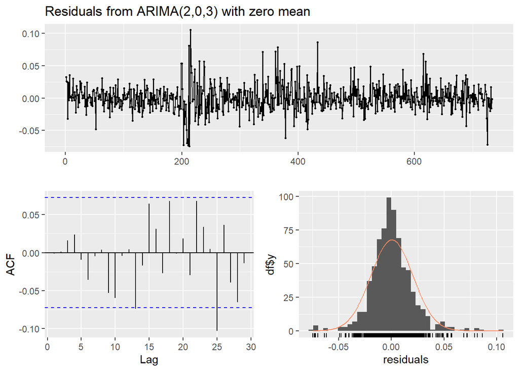

```r
arima22_results <- check_arima(arima22)
```

```
##
##  Ljung-Box test
##
## data:  Residuals from ARIMA(2,0,1) with zero mean
## Q* = 16.046, df = 7, p-value = 0.0247
##
## Model df: 3.   Total lags used: 10
```

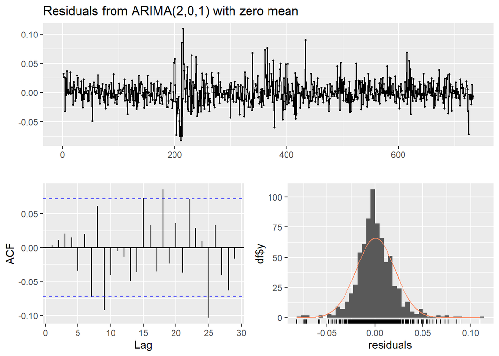

```r
arima23_results <- check_arima(arima23)
```

```
##
##  Ljung-Box test
##
## data:  Residuals from ARIMA(2,0,0) with zero mean
## Q* = 19.554, df = 8, p-value = 0.01216
##
## Model df: 2.   Total lags used: 10
```

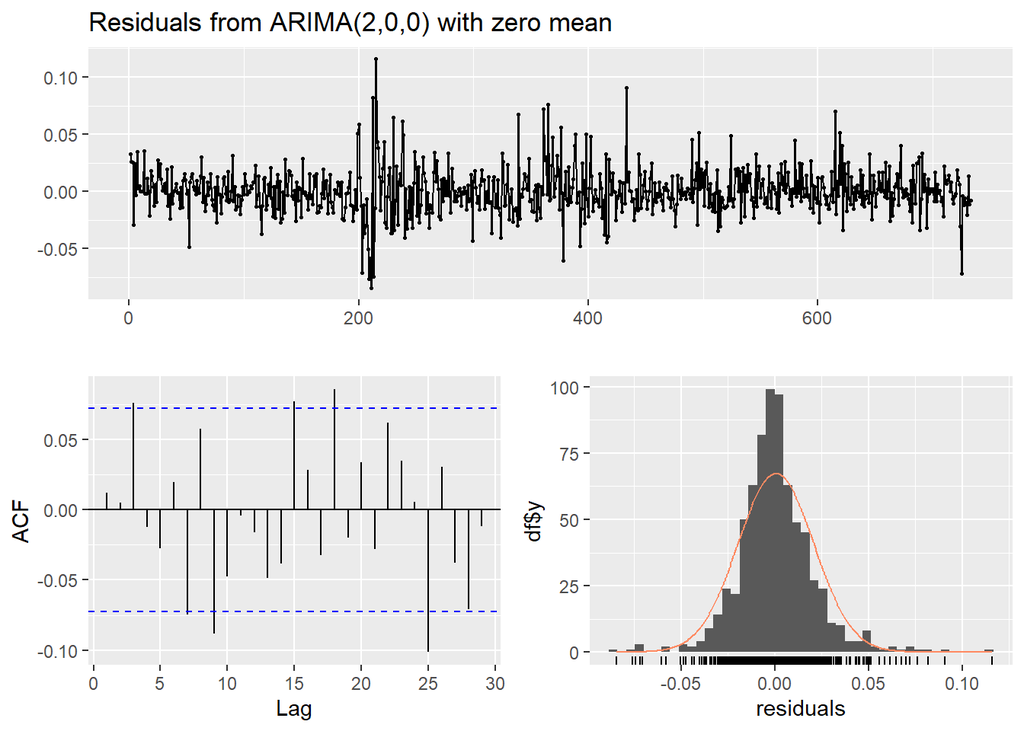

```r
arima27_results <- check_arima(arima27)
```

```
##
##  Ljung-Box test
##
## data:  Residuals from ARIMA(1,0,0) with zero mean
## Q* = 34.206, df = 9, p-value = 8.218e-05
##
## Model df: 1.   Total lags used: 10
```

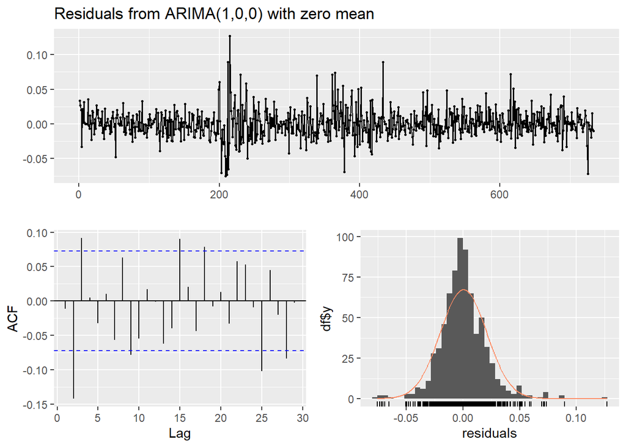

```r
arima28_results <- check_arima(arima28)
```

```
##
##  Ljung-Box test
##
## data:  Residuals from ARIMA(0,0,3) with zero mean
## Q* = 15.884, df = 7, p-value = 0.0262
##
## Model df: 3.   Total lags used: 10
```

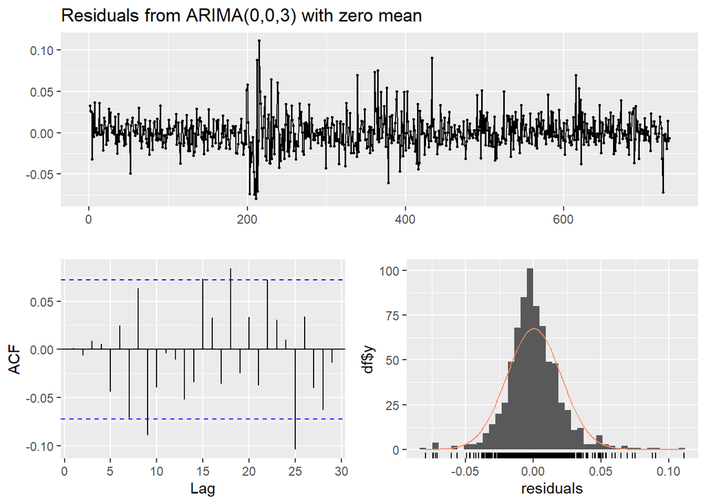

```r
arima30_results <- check_arima(arima30)
```

```
##
##  Ljung-Box test
##
## data:  Residuals from ARIMA(0,0,1) with zero mean
## Q* = 31.528, df = 9, p-value = 0.0002402
##
## Model df: 1.   Total lags used: 10
```

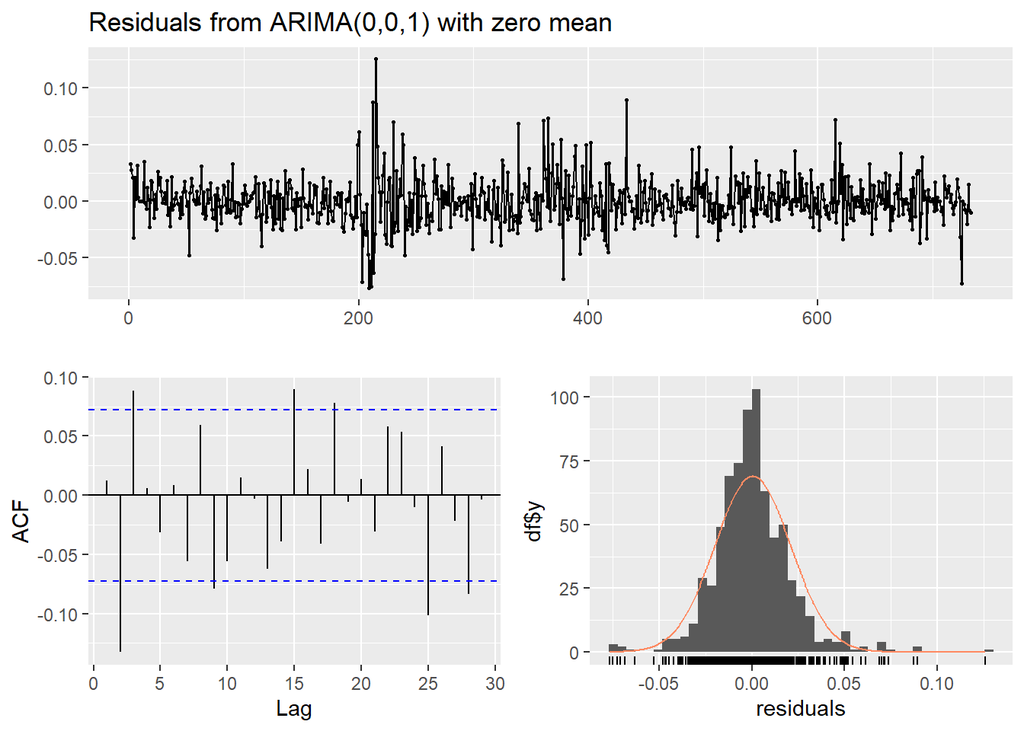

```r
# Combine results into one dataframe
all_results <- rbind(arima17_results, arima20_results, arima22_results, arima23_results, arima27_results, arima28_results, arima30_results)
all_results
```

```
##     Model No_Autokorelasi Stasioner Normal_Residual
## 1 arima17    0.2169384695      0.01               0
## 2 arima20    0.2645035676      0.01               0
## 3 arima22    0.0247019542      0.01               0
## 4 arima23    0.0121632551      0.01               0
## 5 arima27    0.0000821799      0.01               0
## 6 arima28    0.0261982822      0.01               0
## 7 arima30    0.0002401902      0.01               0
```

```r
tabel = cbind(arima17,arima20)
tabel_perbandingan = cbind(tabel[6,],tabel[16,],tabel[5,])
colnames(tabel_perbandingan)=c('AIC','BIC','Loglik')
tabel_perbandingan
```

```
##         AIC       BIC       Loglik
## arima17 -3643.155 -3615.572 1827.577
## arima20 -3643.761 -3616.178 1827.88
```

From both ARIMA models, it can be seen that ARIMA(2,0,3) meets 3 out of 3 of the best model parameter criteria. Therefore, it can be concluded that the best model from the ARIMA method is the ARIMA(2,0,3) model. Next, an ARCH-GARCH analysis will be conducted based on the best model obtained.

```r
# Heteroscedasticity test
ArchTest(residuals(arima20))
```

```
##
##  ARCH LM-test; Null hypothesis: no ARCH effects
##
## data:  residuals(arima20)
## Chi-squared = 115.12, df = 12, p-value < 2.2e-16
```

The p-value is less than 0.05, it indicates that there is significant evidence of ARCH effects (i.e., heteroscedasticity) in the residuals.

```r
# Overfitting ARMA-GARCH

garch11T=garchFit(~arma(2,3)+garch(1,1),data=data2,include.mean=T,trace=
F)
garch10T=garchFit(~arma(2,3)+garch(1,0),data=data2,include.mean=T,trace=
F)
garch11F=garchFit(~arma(2,3)+garch(1,1),data=data2,include.mean=F,trace=
F)
garch10F=garchFit(~arma(2,3)+garch(1,0),data=data2,include.mean=F,trace=
F)
# Model Selection
summary(garch11T)
```

```
##
## Title:
##  GARCH Modelling
##
## Call:
##  garchFit(formula = ~arma(2, 3) + garch(1, 1), data = data2, include.mean = T,
##     trace = F)
##
## Mean and Variance Equation:
##  data ~ arma(2, 3) + garch(1, 1)
## <environment: 0x0000026fcf04f638>
##  [data = data2]
##
## Conditional Distribution:
##  norm
##
## Coefficient(s):
##          mu          ar1          ar2          ma1          ma2          ma3
##  1.2579e-03  -1.0000e+00  -2.8588e-01   8.9769e-01  -1.3195e-02  -2.0384e-01
##       omega       alpha1        beta1
##  2.0692e-05   7.6191e-02   8.6825e-01
##
## Std. Errors:
##  based on Hessian
##
## Error Analysis:
##          Estimate  Std. Error  t value Pr(>|t|)
## mu      1.258e-03   1.195e-03    1.052 0.292618
## ar1    -1.000e+00   3.601e-01   -2.777 0.005489 **
## ar2    -2.859e-01   3.012e-01   -0.949 0.342556
## ma1     8.977e-01   3.772e-01    2.380 0.017325 *
## ma2    -1.319e-02   2.614e-01   -0.050 0.959742
## ma3    -2.038e-01   1.073e-01   -1.899 0.057542 .
## omega   2.069e-05   8.319e-06    2.487 0.012877 *
## alpha1  7.619e-02   2.039e-02    3.737 0.000187 ***
## beta1   8.683e-01   3.768e-02   23.042  < 2e-16 ***
## ---
## Signif. codes:  0 '***' 0.001 '**' 0.01 '*' 0.05 '.' 0.1 ' ' 1
##
## Log Likelihood:
##  1884.924    normalized:  2.571519
##
## Description:
##  Sun Jun  9 13:59:37 2024 by user: Maulida Shabrina
##
##
## Standardised Residuals Tests:
##                                   Statistic      p-Value
##  Jarque-Bera Test   R    Chi^2  260.5448834 0.000000e+00
##  Shapiro-Wilk Test  R    W        0.9693851 2.944458e-11
##  Ljung-Box Test     R    Q(10)   10.7298227 3.789511e-01
##  Ljung-Box Test     R    Q(15)   13.3154894 5.779439e-01
##  Ljung-Box Test     R    Q(20)   16.4121759 6.907469e-01
##  Ljung-Box Test     R^2  Q(10)    7.5707408 6.706859e-01
##  Ljung-Box Test     R^2  Q(15)    8.1808918 9.163258e-01
##  Ljung-Box Test     R^2  Q(20)   11.8155942 9.222768e-01
##  LM Arch Test       R    TR^2     8.2002778 7.692900e-01
##
## Information Criterion Statistics:
##       AIC       BIC       SIC      HQIC
## -5.118482 -5.062037 -5.118779 -5.096709
```

```r
summary(garch10T)
```

```
##
## Title:
##  GARCH Modelling
##
## Call:
##  garchFit(formula = ~arma(2, 3) + garch(1, 0), data = data2, include.mean = T,
##     trace = F)
##
## Mean and Variance Equation:
##  data ~ arma(2, 3) + garch(1, 0)
## <environment: 0x0000026fc98628e0>
##  [data = data2]
##
## Conditional Distribution:
##  norm
##
## Coefficient(s):
##          mu          ar1          ar2          ma1          ma2          ma3
##  0.00195290  -0.99999999  -0.48631288   0.85144714   0.20967476  -0.10555466
##       omega       alpha1
##  0.00030306   0.23704536
##
## Std. Errors:
##  based on Hessian
##
## Error Analysis:
##          Estimate  Std. Error  t value Pr(>|t|)
## mu      1.953e-03   1.336e-03    1.462   0.1438
## ar1    -1.000e+00         NaN      NaN      NaN
## ar2    -4.863e-01         NaN      NaN      NaN
## ma1     8.514e-01         NaN      NaN      NaN
## ma2     2.097e-01   9.276e-02    2.260   0.0238 *
## ma3    -1.056e-01         NaN      NaN      NaN
## omega   3.031e-04   2.121e-05   14.288  < 2e-16 ***
## alpha1  2.370e-01   6.049e-02    3.919 8.89e-05 ***
## ---
## Signif. codes:  0 '***' 0.001 '**' 0.01 '*' 0.05 '.' 0.1 ' ' 1
##
## Log Likelihood:
##  1854.655    normalized:  2.530225
##
## Description:
##  Sun Jun  9 13:59:37 2024 by user: Maulida Shabrina
##
##
## Standardised Residuals Tests:
##                                   Statistic      p-Value
##  Jarque-Bera Test   R    Chi^2  426.7684526 0.000000e+00
##  Shapiro-Wilk Test  R    W        0.9555309 4.356351e-14
##  Ljung-Box Test     R    Q(10)   16.7086032 8.106569e-02
##  Ljung-Box Test     R    Q(15)   23.5383762 7.335888e-02
##  Ljung-Box Test     R    Q(20)   28.2320491 1.040191e-01
##  Ljung-Box Test     R^2  Q(10)   50.9005935 1.821756e-07
##  Ljung-Box Test     R^2  Q(15)   71.6517380 2.265082e-09
##  Ljung-Box Test     R^2  Q(20)   79.4188073 4.926100e-09
##  LM Arch Test       R    TR^2    50.7161837 1.045260e-06
##
## Information Criterion Statistics:
##       AIC       BIC       SIC      HQIC
## -5.038622 -4.988448 -5.038857 -5.019268
```

```r
summary(garch11F)
```

```
##
## Title:
##  GARCH Modelling
##
## Call:
##  garchFit(formula = ~arma(2, 3) + garch(1, 1), data = data2, include.mean = F,
##     trace = F)
##
## Mean and Variance Equation:
##  data ~ arma(2, 3) + garch(1, 1)
## <environment: 0x0000026fc990f330>
##  [data = data2]
##
## Conditional Distribution:
##  norm
##
## Coefficient(s):
##         ar1          ar2          ma1          ma2          ma3        omega
## -1.0000e+00  -2.8913e-01   8.9884e-01  -8.0327e-03  -2.0184e-01   2.0585e-05
##      alpha1        beta1
##  7.4297e-02   8.7039e-01
##
## Std. Errors:
##  based on Hessian
##
## Error Analysis:
##          Estimate  Std. Error  t value Pr(>|t|)
## ar1    -1.000e+00   3.312e-01   -3.019 0.002536 **
## ar2    -2.891e-01   2.799e-01   -1.033 0.301649
## ma1     8.988e-01   3.476e-01    2.586 0.009707 **
## ma2    -8.033e-03   2.459e-01   -0.033 0.973938
## ma3    -2.018e-01   1.015e-01   -1.988 0.046793 *
## omega   2.059e-05   8.199e-06    2.511 0.012052 *
## alpha1  7.430e-02   1.947e-02    3.816 0.000136 ***
## beta1   8.704e-01   3.651e-02   23.837  < 2e-16 ***
## ---
## Signif. codes:  0 '***' 0.001 '**' 0.01 '*' 0.05 '.' 0.1 ' ' 1
##
## Log Likelihood:
##  1884.253    normalized:  2.570605
##
## Description:
##  Sun Jun  9 13:59:38 2024 by user: Maulida Shabrina
##
##
## Standardised Residuals Tests:
##                                  Statistic      p-Value
##  Jarque-Bera Test   R    Chi^2  267.641046 0.000000e+00
##  Shapiro-Wilk Test  R    W        0.968861 2.228598e-11
##  Ljung-Box Test     R    Q(10)   10.619040 3.879577e-01
##  Ljung-Box Test     R    Q(15)   13.259311 5.822765e-01
##  Ljung-Box Test     R    Q(20)   16.388410 6.922544e-01
##  Ljung-Box Test     R^2  Q(10)    8.223570 6.070091e-01
##  Ljung-Box Test     R^2  Q(15)    8.888210 8.832896e-01
##  Ljung-Box Test     R^2  Q(20)   12.358322 9.031909e-01
##  LM Arch Test       R    TR^2     8.973989 7.051505e-01
##
## Information Criterion Statistics:
##       AIC       BIC       SIC      HQIC
## -5.119381 -5.069208 -5.119616 -5.100028
```

```r
summary(garch10F)
```

```
##
## Title:
##  GARCH Modelling
##
## Call:
##  garchFit(formula = ~arma(2, 3) + garch(1, 0), data = data2, include.mean = F,
##     trace = F)
##
## Mean and Variance Equation:
##  data ~ arma(2, 3) + garch(1, 0)
## <environment: 0x0000026fcb5749f0>
##  [data = data2]
##
## Conditional Distribution:
##  norm
##
## Coefficient(s):
##         ar1          ar2          ma1          ma2          ma3        omega
## -0.99999999  -0.48493741   0.85433498   0.20815756  -0.10623357   0.00030699
##      alpha1
##  0.22582391
##
## Std. Errors:
##  based on Hessian
##
## Error Analysis:
##          Estimate  Std. Error  t value Pr(>|t|)
## ar1    -1.000e+00         NaN      NaN      NaN
## ar2    -4.849e-01         NaN      NaN      NaN
## ma1     8.543e-01         NaN      NaN      NaN
## ma2     2.082e-01   9.019e-02    2.308 0.021001 *
## ma3    -1.062e-01         NaN      NaN      NaN
## omega   3.070e-04   2.122e-05   14.466  < 2e-16 ***
## alpha1  2.258e-01   5.874e-02    3.845 0.000121 ***
## ---
## Signif. codes:  0 '***' 0.001 '**' 0.01 '*' 0.05 '.' 0.1 ' ' 1
##
## Log Likelihood:
##  1853.628    normalized:  2.528825
##
## Description:
##  Sun Jun  9 13:59:38 2024 by user: Maulida Shabrina
##
##
## Standardised Residuals Tests:
##                                   Statistic      p-Value
##  Jarque-Bera Test   R    Chi^2  443.4788614 0.000000e+00
##  Shapiro-Wilk Test  R    W        0.9547631 3.168272e-14
##  Ljung-Box Test     R    Q(10)   16.4552050 8.732212e-02
##  Ljung-Box Test     R    Q(15)   23.3736315 7.652274e-02
##  Ljung-Box Test     R    Q(20)   28.1651735 1.055467e-01
##  Ljung-Box Test     R^2  Q(10)   50.3759361 2.276059e-07
##  Ljung-Box Test     R^2  Q(15)   71.6980146 2.222287e-09
##  Ljung-Box Test     R^2  Q(20)   78.3010578 7.612066e-09
##  LM Arch Test       R    TR^2    50.8233144 1.000787e-06
##
## Information Criterion Statistics:
##       AIC       BIC       SIC      HQIC
## -5.038550 -4.994648 -5.038730 -5.021615
```

Overall, the best ARMA-GARCH model is the garch11F model because it has the smallest AIC and BIC values and there are no ARCH effects in the residuals.

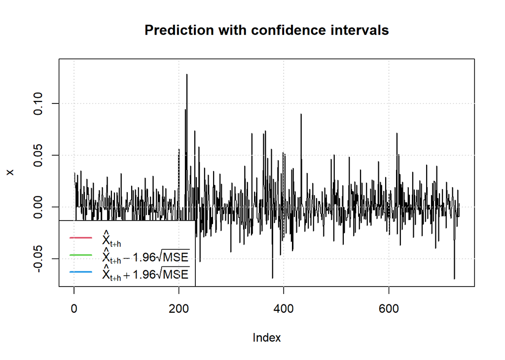

```
##   meanForecast  meanError standardDeviation lowerInterval upperInterval
## 1  0.003699791 0.01975684        0.01975684    -0.0350229    0.04242249
```

```r
# Forecast
predict(garch11F, n.ahead=1,plot=T,nx=734)
```

```r
p = 4170
rt = 0.003699791
pt = exp(log(p)+rt)
pt
```

```
## [1] 4185.457
```

It can be concluded that the forecasted stock value on May 23, 2022, is 4186.